# Ancestral state reconstruction simulations

Andrew Du

January 31, 2017

## The goal of these sets of simulations is to see if ancestral state reconstructions (assuming a Brownian motion model of evolution) can recover a morphological trend.

### 1) First, I’ll simulate a random phylogenetic tree. Code from http://www.phytools.org/eqg/Exercise_4.1/

Load packages.

```r
library(phytools)
library(ape)
library(apTreeshape)
library(plyr)
library(abind)
```

Simulate a random birth-death tree.

```r
Time <- 100  # total time
n <- 30  # total taxa
b <- (log(n) - log(2))/Time # speciation rate

tree <- pbtree(b = b, n = n, t = Time, type = "continuous")
```

```
## simulating with both taxa-stop (n) and time-stop (t) is
## performed via rejection sampling & may be slow
##
##   24 trees rejected before finding a tree
```

Plot the tree.

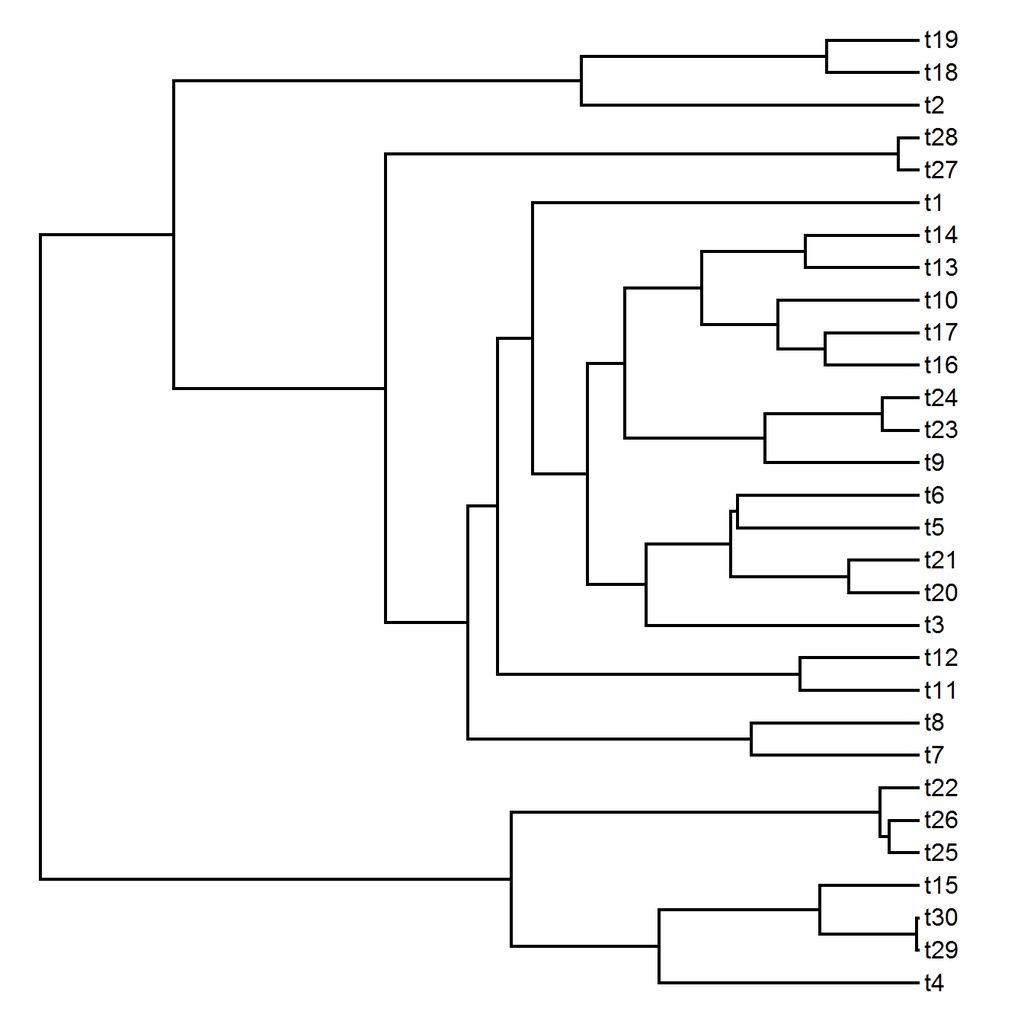

```r
plotTree(tree)
```

### 2) Next, I’ll simulate morphological evolution along this tree with a trend.

```r
a <- 0 # ancestral state
mu <- 0.01 # mean of random normal changes, i.e., "strength" of trend
sig2 <- 0.01 # variance of random normal changes, i.e., how noisy the trend is

x <- fastBM(tree, a=a, mu=mu, sig2=sig2, internal=TRUE)
```

Plot the tree and morphological trend as a phenogram.

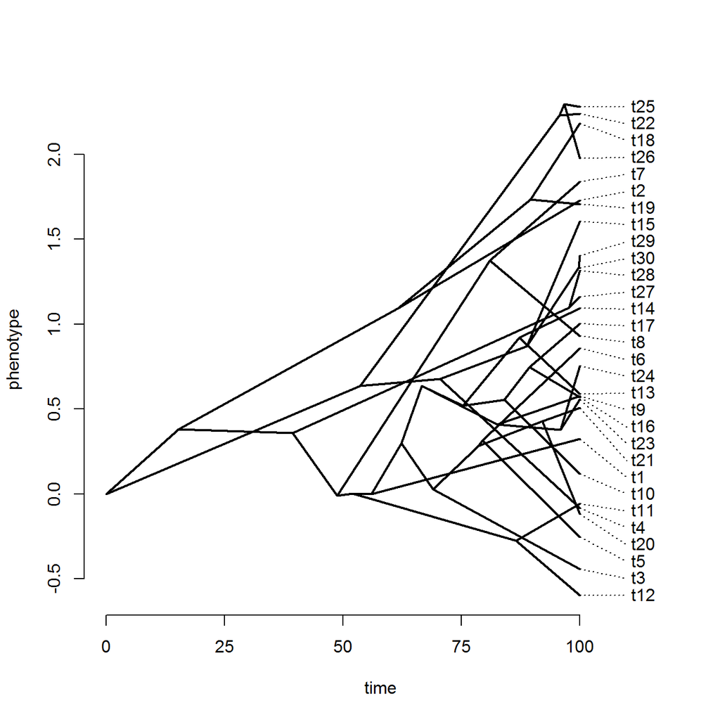

```r
phenogram(tree, x, spread.labels = TRUE, spread.cost = c(1, 0))
```

### 3) Reconstruct ancestral states of nodes assuming a Brownian motion model of evolution.

```r
tip.morph <- x[grep("t", names(x))] # morphological measurements of tip data
node.morph <- x[-grep("t", names(x))] # morphological measurements of node data

anc <- ace(tip.morph, tree, type="continuous") # ancestral state reconstruction assuming Brownian motion
```

Plot the tree along with “observed” tip morphological measurements and reconstructed node estimates. Size of the points is proportional to the magnitude of the morphological trait

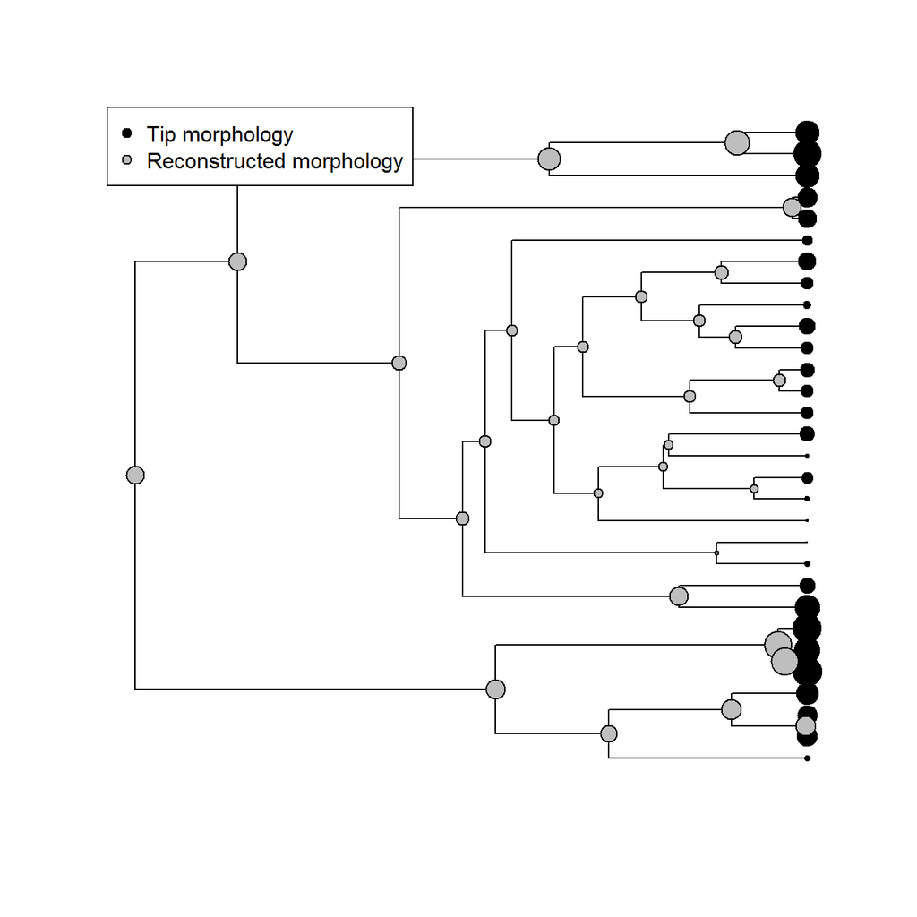

```r
# following code is from https://www.r-phylo.org/wiki/HowTo/Ancestral_State_Reconstruction
plot(tree, show.tip.label=FALSE)
tiplabels(pch=21, cex=tip.morph - min(tip.morph) + 0.1, bg="black")
nodelabels(pch = 21, cex=anc$ace - min(tip.morph) + 0.1, bg="gray")

legend("topleft", c("Tip morphology", "Reconstructed morphology"), pch=c(21, 21), pt.bg=c("black", "gray"))
```

Plots of node morphology (“true” and reconstructed using Brownian motion model) vs. branching times along with respective slope estimates.

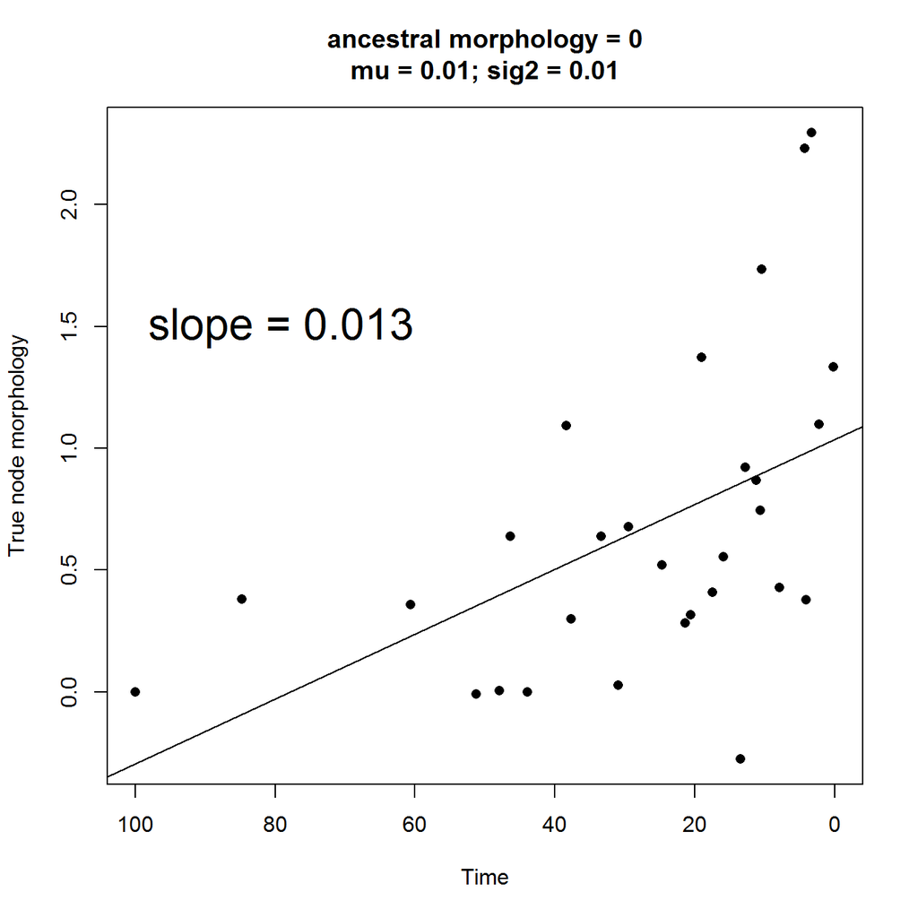

```r
plot(branching.times(tree), node.morph, xlim=c(100, 0), pch=16, ylab="True node morphology", xlab="Time", main="ancestral morphology = 0\nmu = 0.01; sig2 = 0.01") # NB: time is reversed relative to the phenogram.
node.lm <- lm(node.morph ~ branching.times(tree))
abline(node.lm)
text(100, 1.5, paste0("slope = ", round(-1 * node.lm$coef[2], 3)), pos=4, cex=2)
```

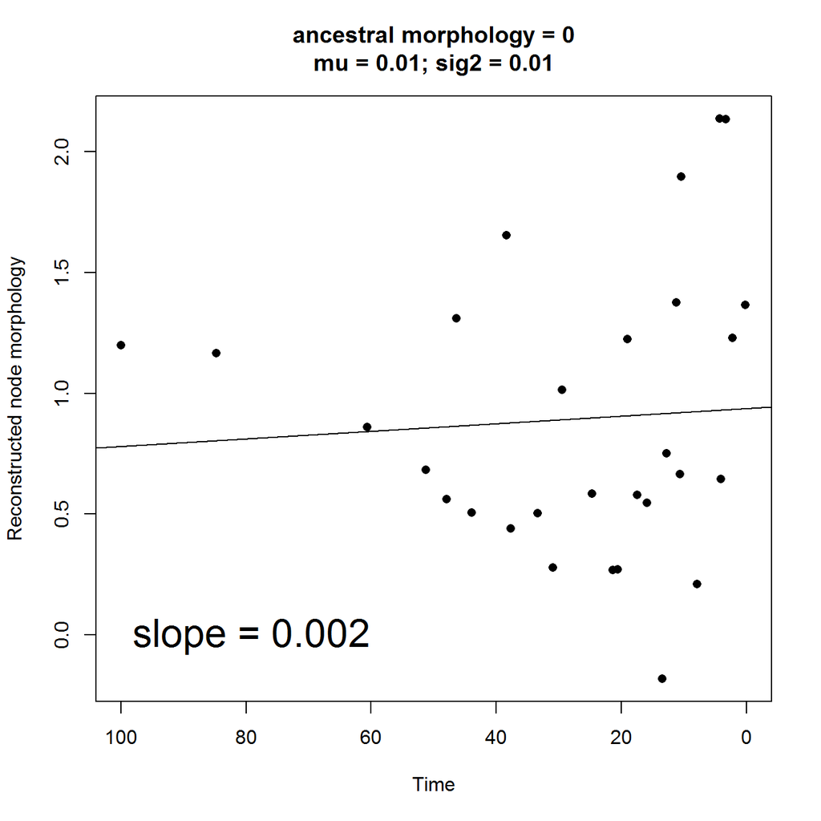

```r
plot(branching.times(tree), anc$ace, xlim=c(100, 0), pch=16, ylab="Reconstructed node morphology", xlab="Time", main="ancestral morphology = 0\nmu = 0.01; sig2 = 0.01") # NB: time is reversed relative to the phenogram.
ace.lm <- lm(anc$ace ~ branching.times(tree))
abline(ace.lm)
text(100, 0, paste0("slope = ", round(-1 * ace.lm$coef[2], 3)), pos=4, cex=2)
```

### These results show that reconstructing ancestral states using a Brownian motion model is unable to recover the true underlying trend (which is relatively weak). Can simulate a trend and iterate the entire process multiple times to see how noisy this pattern is.

```r
a <- 0 # ancestral state
mu <- 0.01 # mean of random normal changes, i.e., "strength" of trend
sig2 <- 0.01 # variance of random normal changes, i.e., how noisy the trend is
n.iter <- 1000 # number of iterations

node.slope <- anc.slope <- numeric(n.iter)

for(i in seq_len(n.iter)){

  morph <- fastBM(tree, a=a, mu=mu, sig2=sig2, internal=TRUE)

  tip.morph1 <- morph[grep("t", names(morph))] # morphological measurements of tip data
  node.morph1 <- morph[-grep("t", names(morph))] # morphological measurements of node data

  anc1 <- ace(tip.morph1, tree, type="continuous") # ancestral state reconstruction assuming Brownian motion

  node.slope[i] <- lm(node.morph1 ~ branching.times(tree))$coef[2] * -1
  anc.slope[i] <- lm(anc1$ace ~ branching.times(tree))$coef[2] * -1
}
```

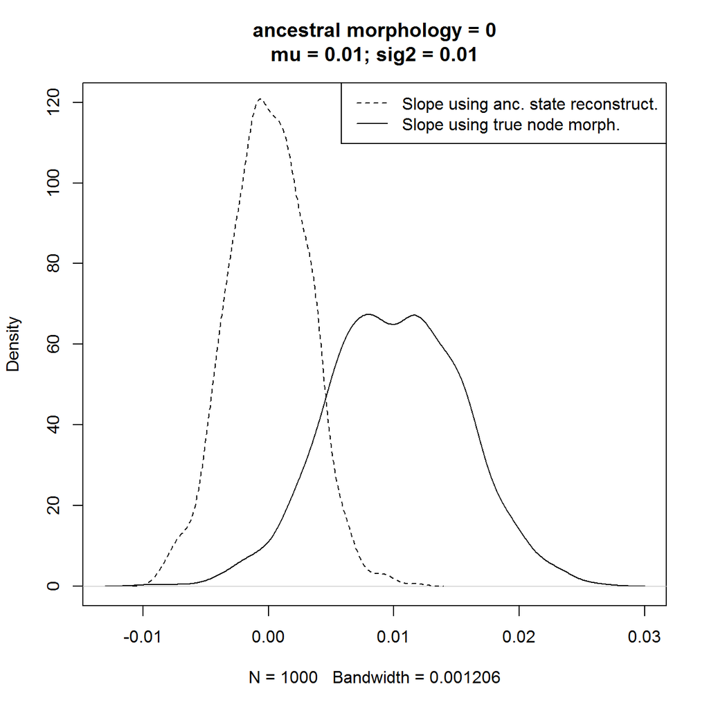

```r
plot(density(node.slope), main="ancestral morphology = 0\nmu = 0.01; sig2 = 0.01", ylim=c(0, 120))
lines(density(anc.slope), lty=2)

legend("topright", c("Slope using anc. state reconstruct.", "Slope using true node morph."), lty=c(2, 1))
```

### When iterated 1000 times, the slope of the true node morphology against time approaches 0.01 (which is the expected value since mu = 0.01), illustrating the strength of the underlying trend. The slope of the reconstructed ancestral states vs. time is centered around 0, which is the expected mean change of a Brownian motion model (i.e., increases and decreases are equiprobable). This means using Brownian motion to reconstruct ancestral states cannot recover the true trend. I’m sure there’s a mathematical proof out there that can demonstrate this, given how closely the iterations align with what is mathematically expected.

## What if the strength of these results depends on the structure of the tree? I will simulate 10 more random trees (keeping total time, total number of taxa, and speciation rate the same) and repeat all of the above analyses.

### 1) Simulate each tree.

```r
Time <- 100  # total time
n <- 30  # total taxa
b <- (log(n) - log(2))/Time # speciation rate

tree.list <- pbtree(b = b, n = n, t = Time, type = "continuous", nsim=10)
```

[output not shown]

### 2) Simulate a morphological trend on each tree (keeping the same parameters as before), and 3) reconstruct ancestral states for each tree, assuming a Brownian motion model of evolution. Make this into a function, so downstream analyses are easier.

```r
slope.func <- function(tree.list, a, mu, sig2, n.iter){

  require(phytools)
  require(ape)
  require(abind)

  Morph <- lapply(tree.list, function(x) fastBM(x, a=a, mu=mu, sig2=sig2, internal=TRUE, nsim=n.iter)) # simulate a trended morphology for each tree for a given number of iterations

  Tip.morph <- lapply(Morph, function(x) x[grep("t", rownames(x)), ]) # get out tip morphology for each tree for each iteration
  Node.morph <- lapply(Morph, function(x) x[-grep("t", rownames(x)), ]) # get out node morphology for each tree for each iteration

  # do ancestral state reconstruction for each tree for each iteration (rows are iterations, columns are different trees)
  ace.res <- mapply(function(x, y){

    apply(x, 2, function(z) ace(z, y)$ace)

  }, Tip.morph, tree.list, SIMPLIFY=FALSE)


  branch.times <- lapply(tree.list, branching.times) # branching times for each tree (rows are different branching times, columns are different trees)

  # regress "real" node morphology on branching times
  node.coef <- mapply(function(node, branch){

    apply(node, 2, function(node.col) lm(node.col ~ branch)$coef[2] * -1)

  }, Node.morph, branch.times)


  # regress reconstructed ancestral states on branching times
  ace.coef <- mapply(function(ace1, branch){

    apply(ace1, 2, function(ace.col) lm(ace.col ~ branch)$coef[2] * -1)

  }, ace.res, branch.times)


  return(abind(node.coef, ace.coef, along=0))
}
```

Run function.

```r
res <- slope.func(tree.list, a=0, mu=0.01, sig2=0.01, n.iter=100)
```

Results plotted with the tree first, then density plot second.

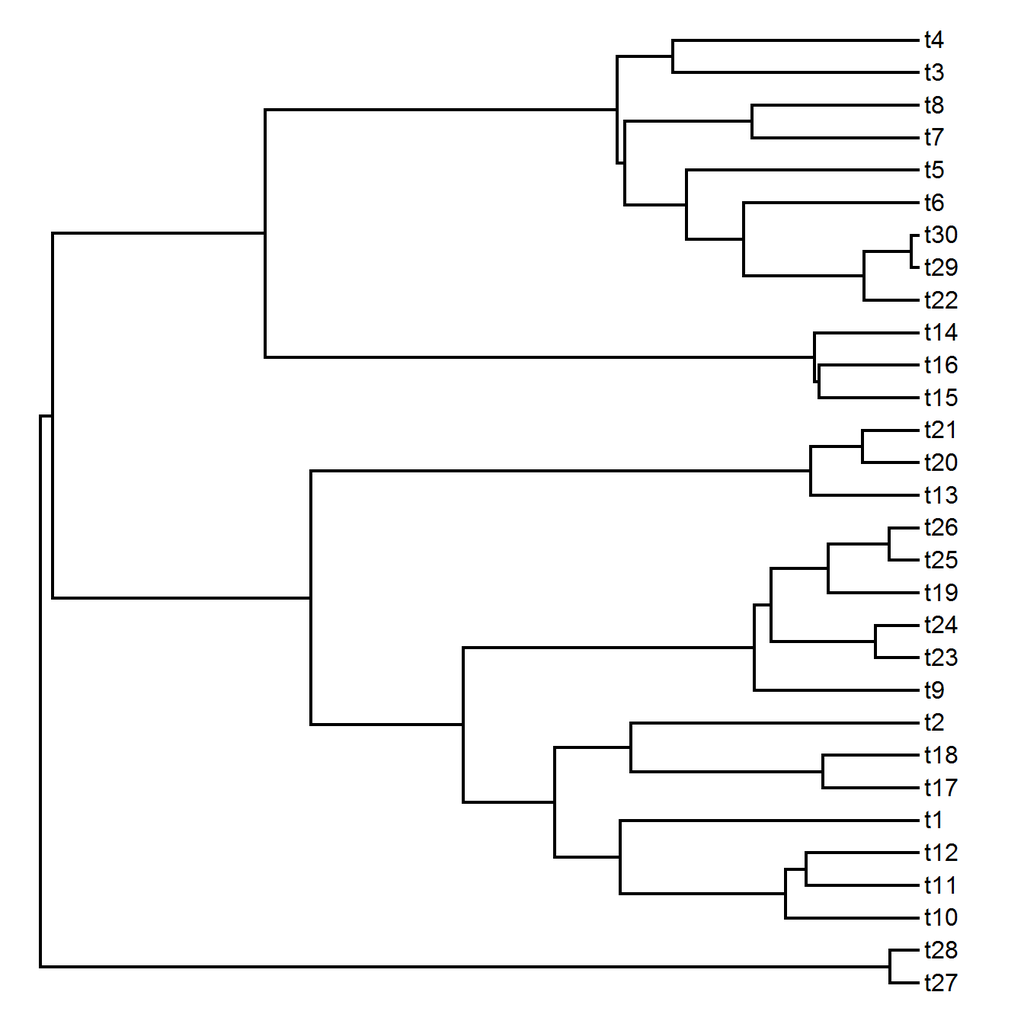

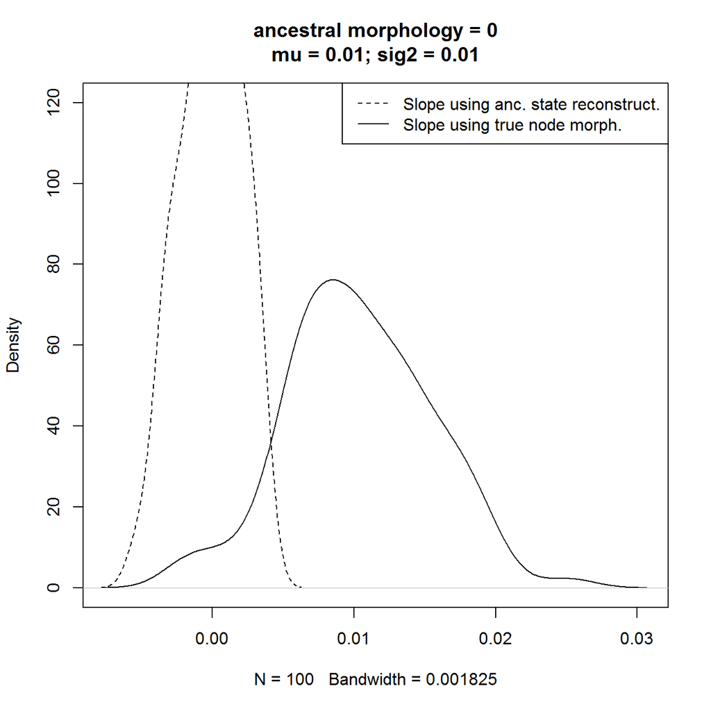

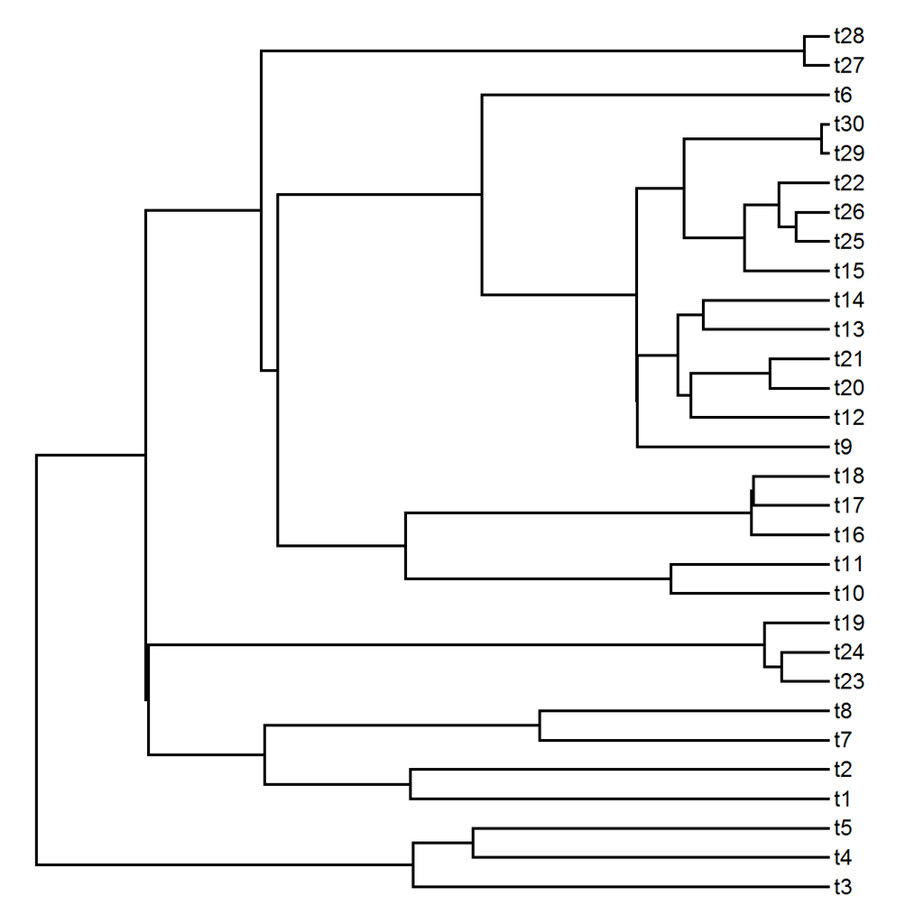

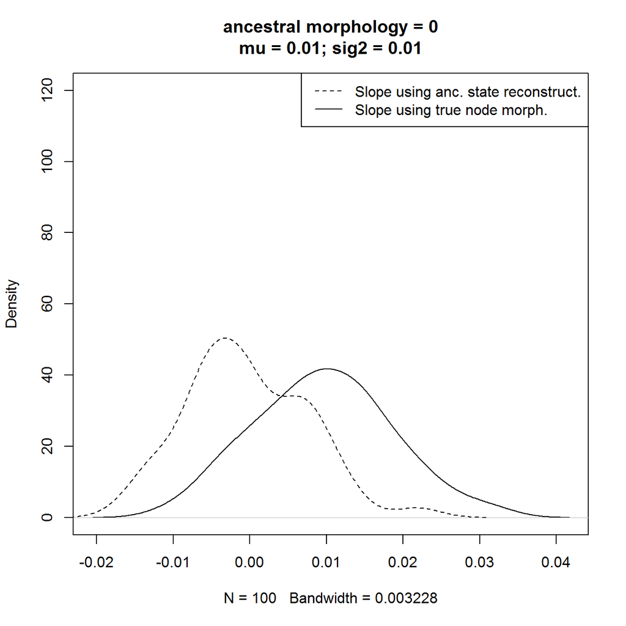

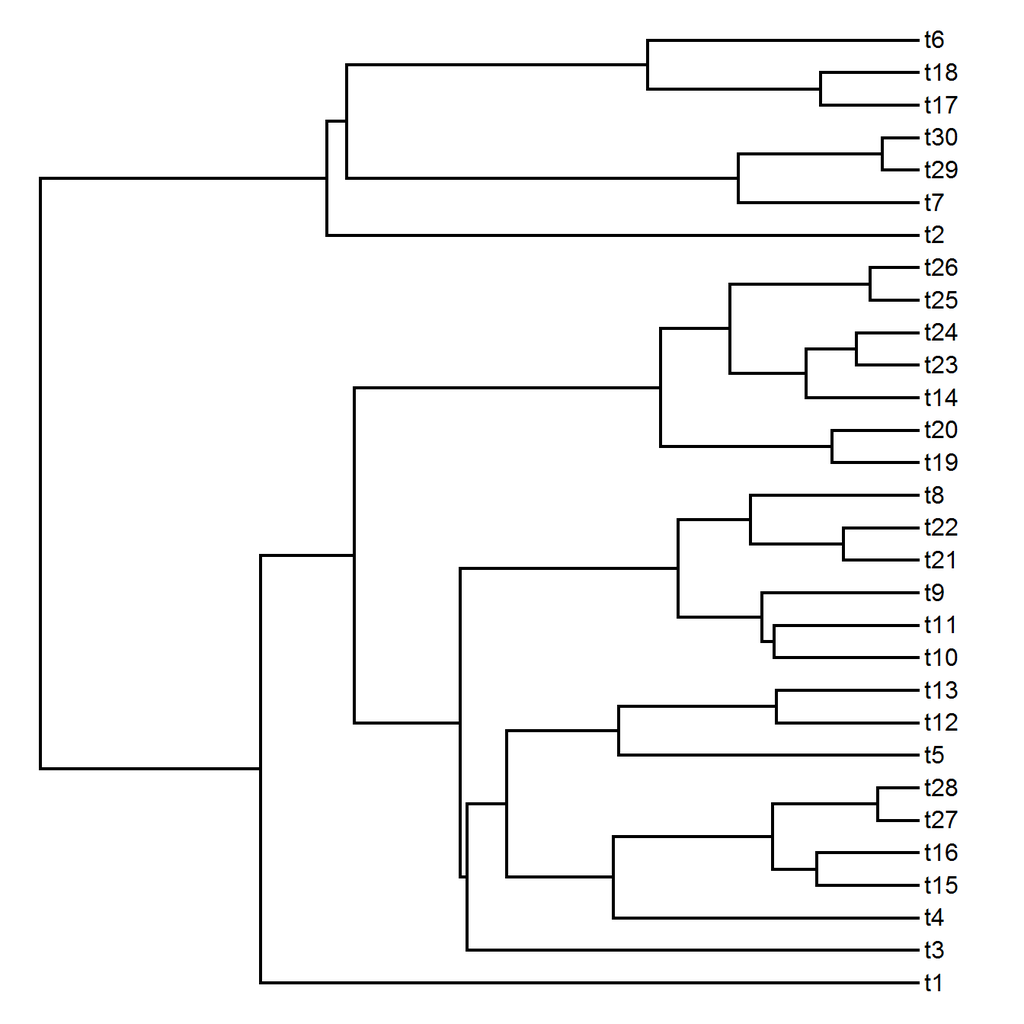

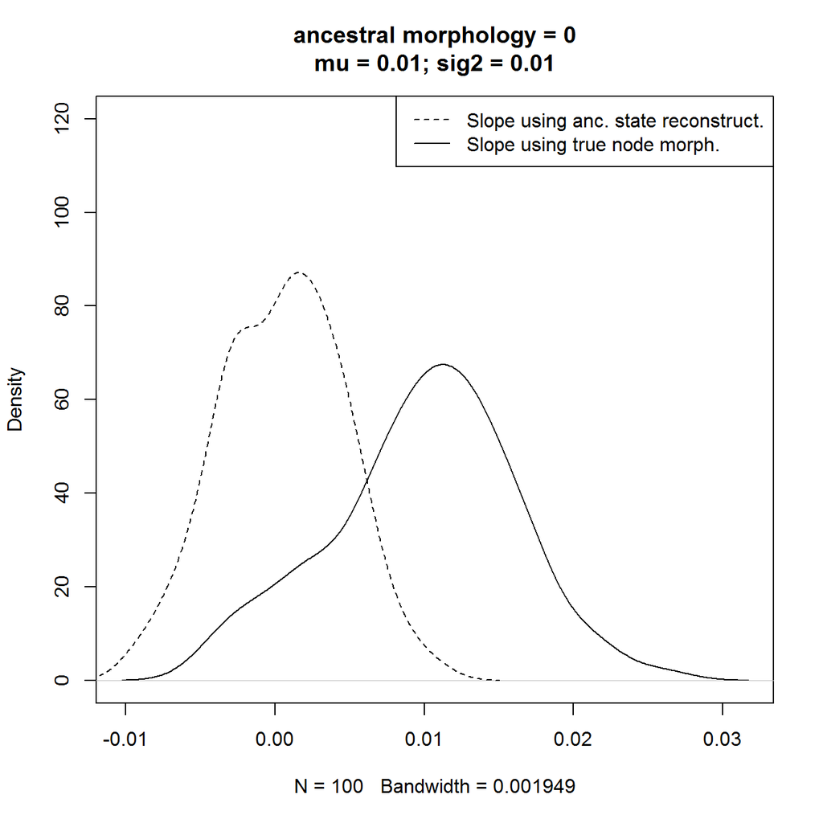

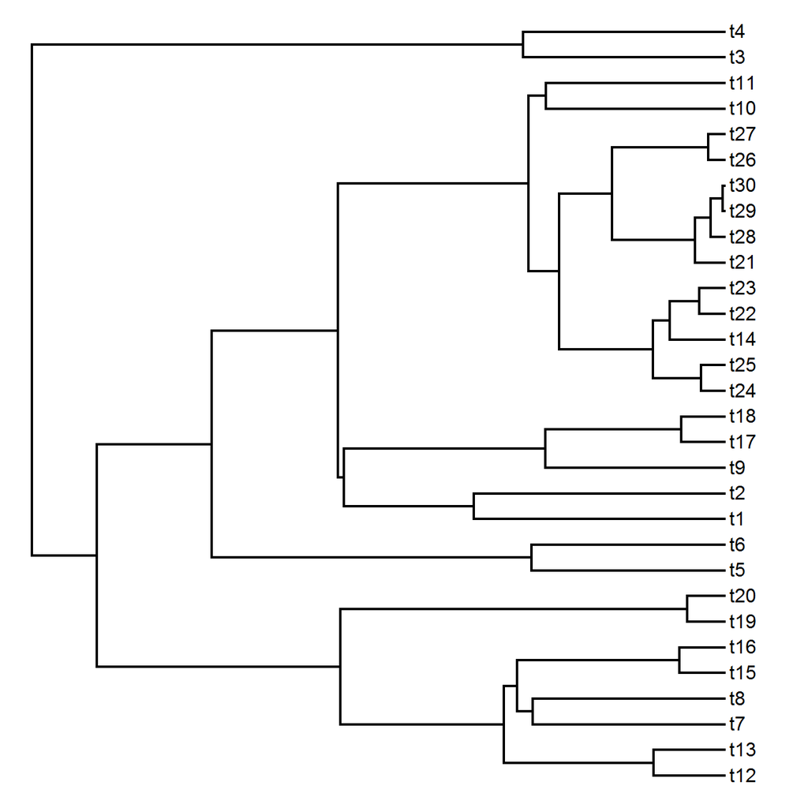

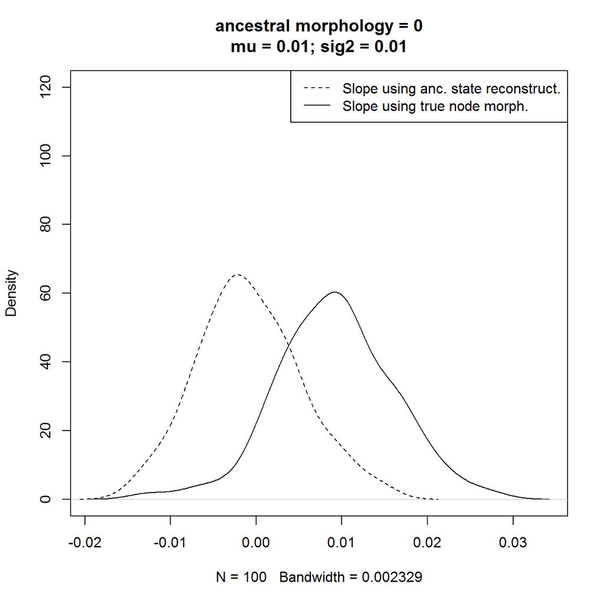

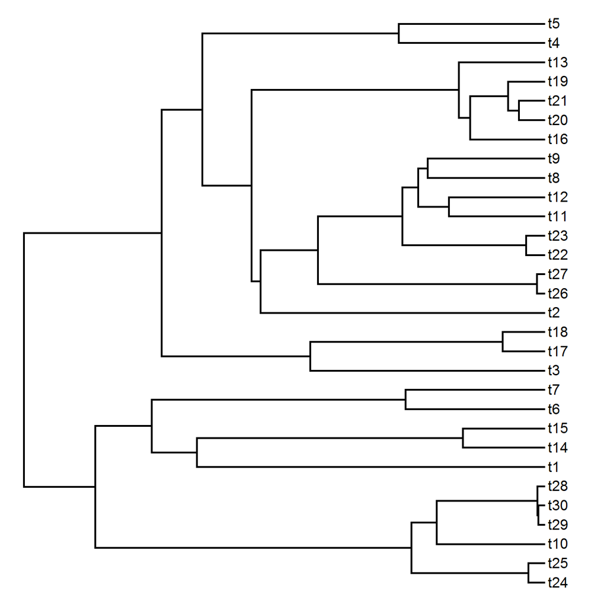

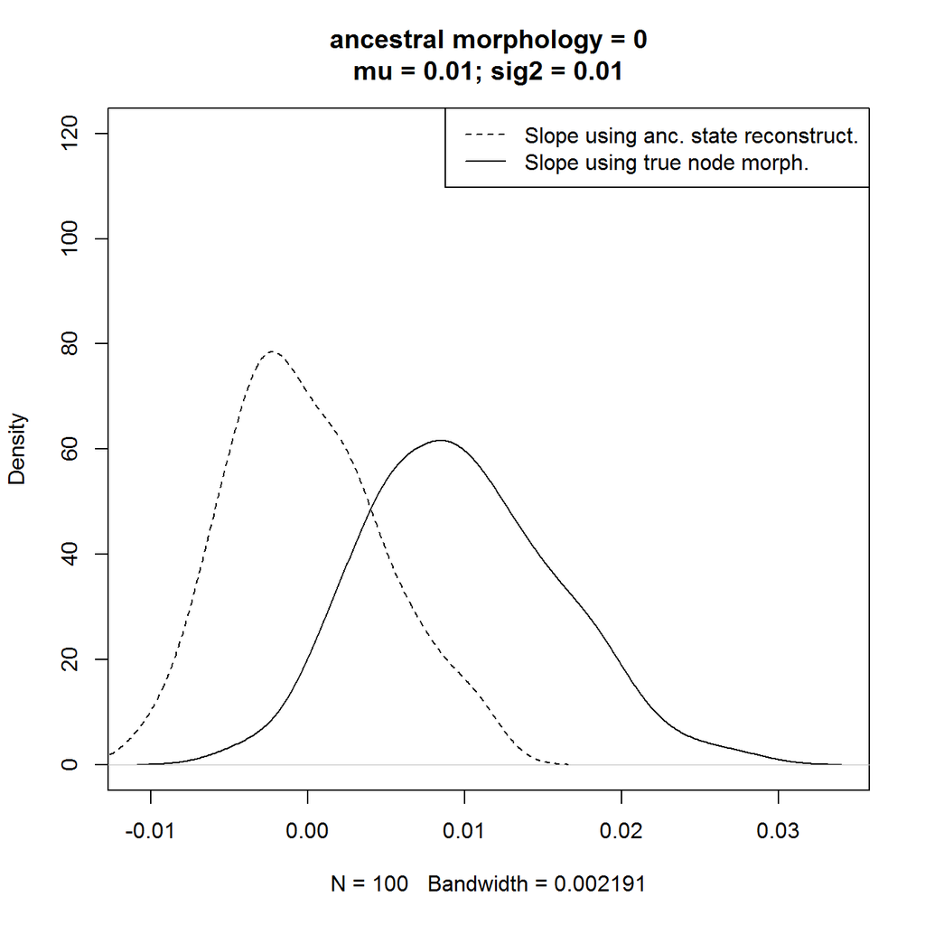

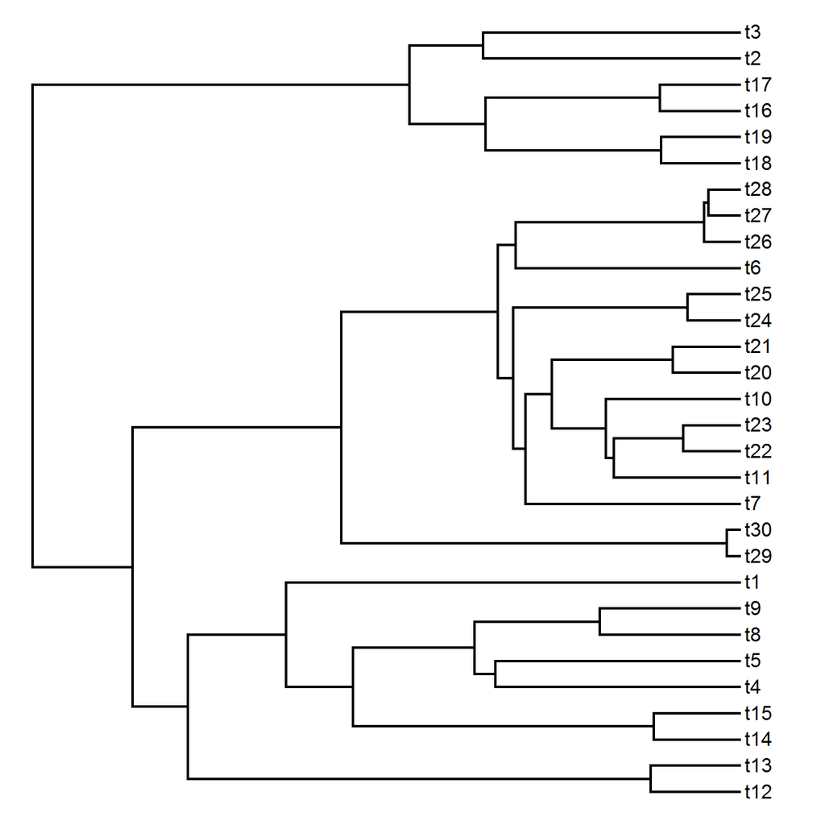

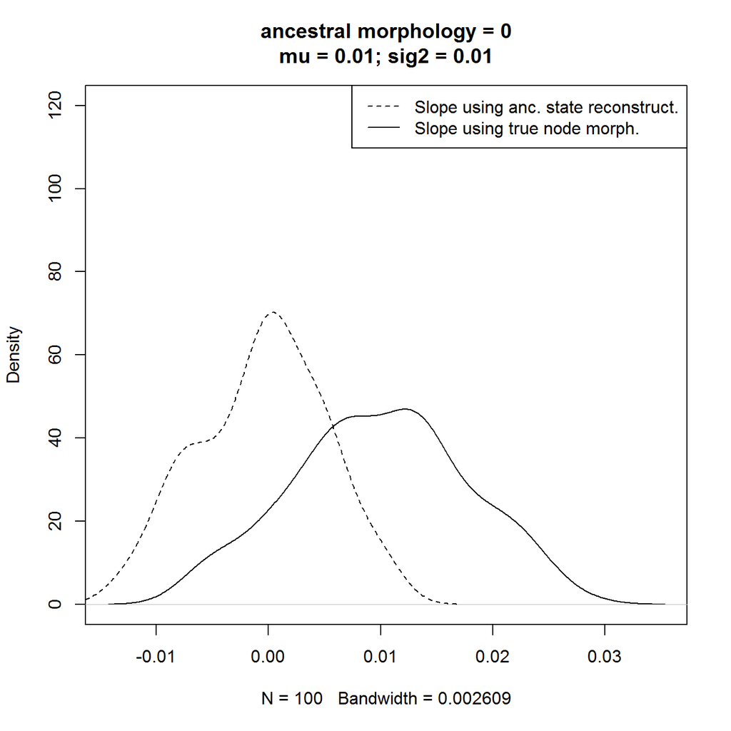

[8 more figures not shown]

```r
for(i in seq_along(tree.list)){

  plotTree(tree.list[[i]])

  par(mar=c(5, 4, 4, 2) + 0.1)

  plot(density(res[1, , i]), main="ancestral morphology = 0\nmu = 0.01; sig2 = 0.01", ylim=c(0, 120))
  lines(density(res[2, , i]), lty=2)

  legend("topright", c("Slope using anc. state reconstruct.", "Slope using true node morph."), lty=c(2, 1))
}
```

### In general the results are the same no matter what the structure of the tree is, so the results are fairly robust. That is, using reconstructing ancestral states assuming a Brownian motion evolutionary model is unable to recover the underlying trend. There is variation in the density plots, however, and I assume it is driven by how balanced the tree is.

## Therefore, for my final set of simulations, I’ll try to create very balanced and unbalanced trees and then run the above analyses. I will simulate a bunch of random trees and then select trees that are very balanced or unbalanced.

### 1) Simulate 1000 random trees.

```r
# simulate 1000 trees
numtrees <- 1000
Time <- 100  # total time
n <- 30  # total taxa
b <- (log(n) - log(2))/Time # speciation rate

trees <- invisible(pbtree(b = b, n = 30, t = Time, nsim = numtrees))
```

[output not shown]

[output cut: 4944 more lines]

[output not shown]

### 2) Figure out which trees are very balanced and unbalanced.

Function for determining whether trees are balanced or not. Code from https://www.r-bloggers.com/exploring-phylogenetic-tree-balance-metrics/

```r
foo <- function(x, metric = "colless") {
  require(apTreeshape)

  if (metric == "colless") {
      xx <- as.treeshape(x)  # convert to apTreeshape format
      colless(xx, "yule")  # calculate colless' metric
  } else if (metric == "gamma") {
      gammaStat(x)
  } else stop("metric should be one of colless or gamma")
}
```

Calculate Colless’ index for each tree

```r
colless_df <- ldply(trees, foo, metric = "colless")  # calculate metric for each tree
```

See which trees fall into the cutoff for balanced and unbalanced trees. I’m just looking for very (un)balanced trees, so it doesn’t matter if the cut-off is symmetrical or not.

```r
trees.balanced <- trees[colless_df < -1]
length(trees.balanced)
```

```
## [1] 47
```

```r
trees.unbalanced <- trees[colless_df > 1]
length(trees.unbalanced)
```

```
## [1] 94
```

Here’s a sample of some balanced trees.

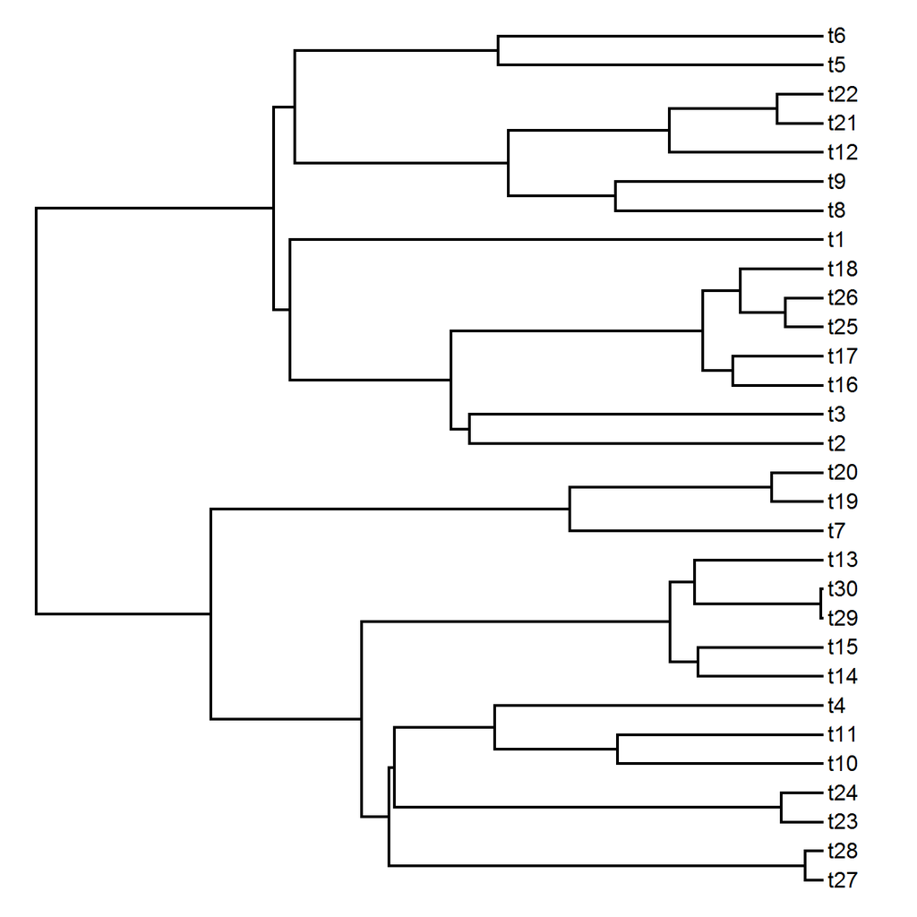

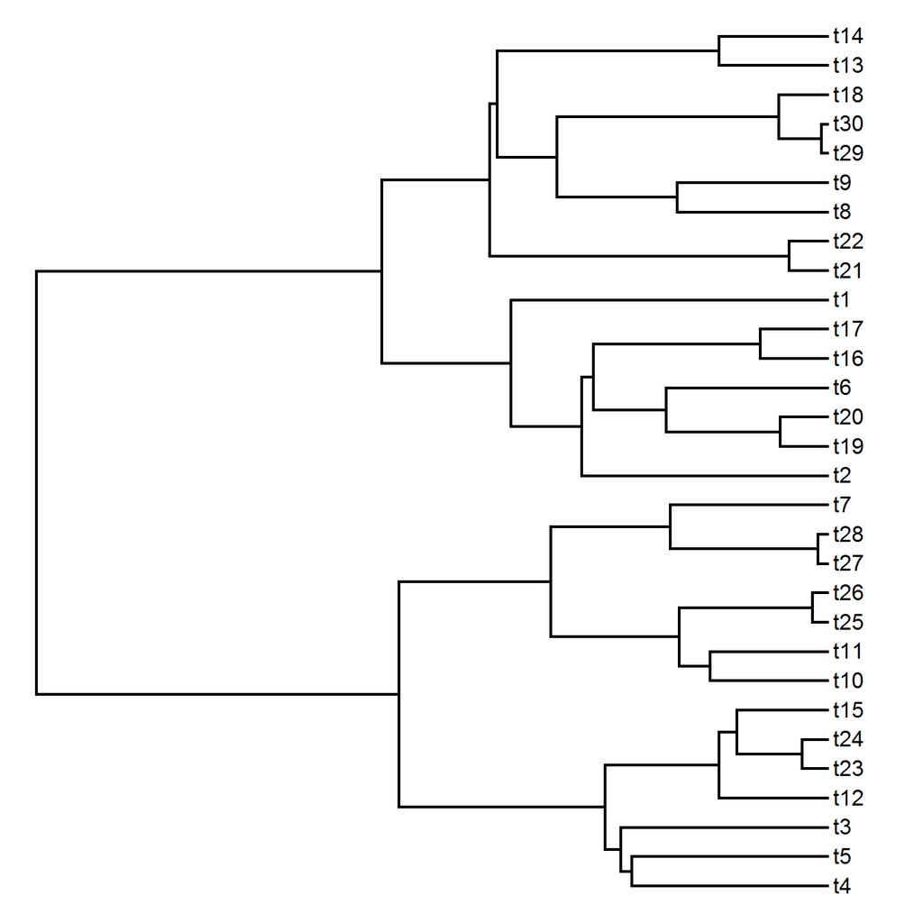

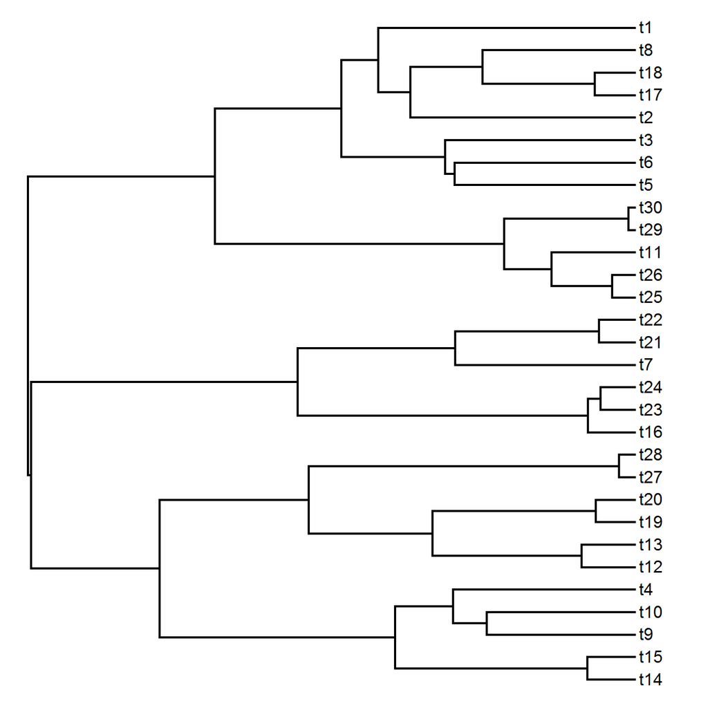

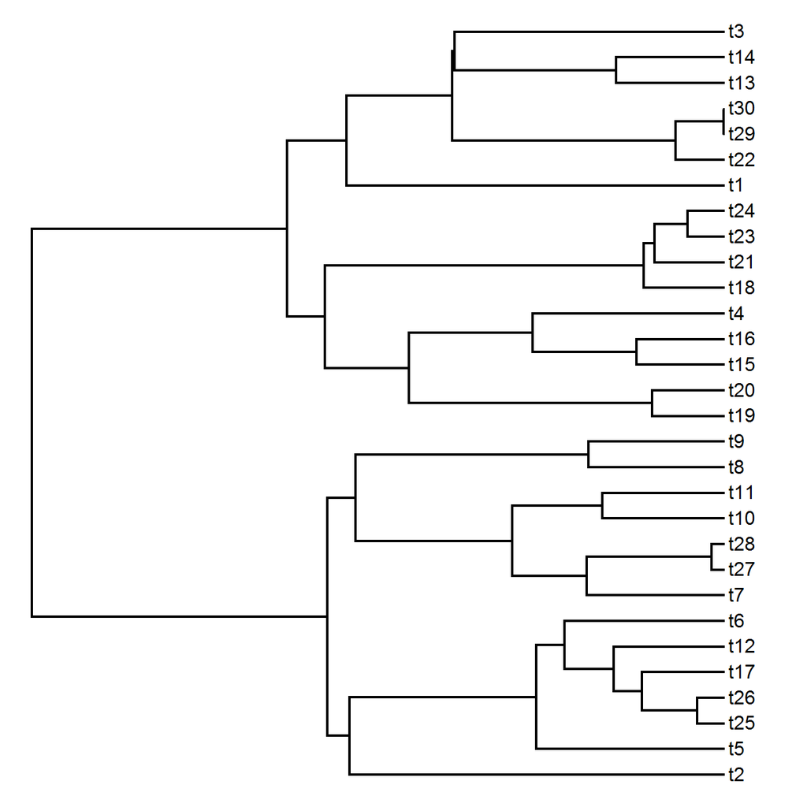

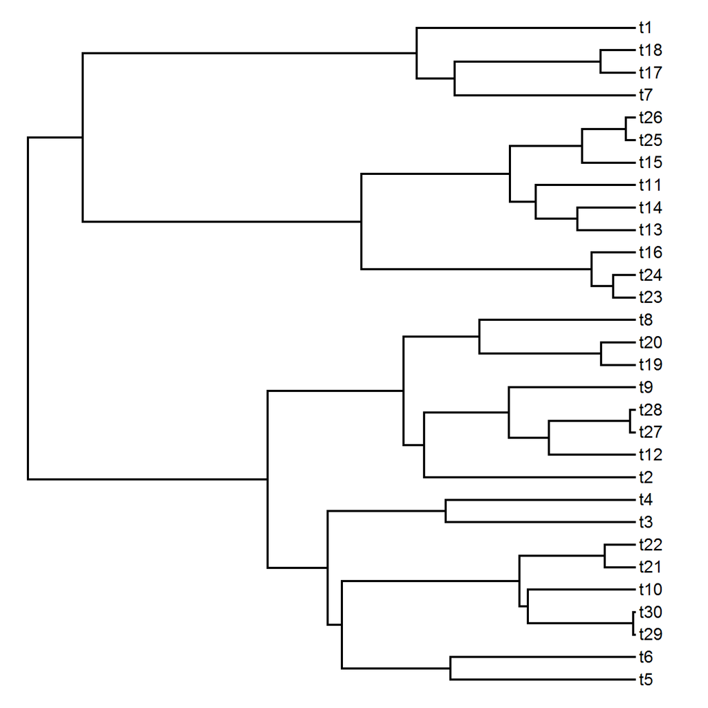

```r
plotTree(trees.balanced[1:5], main="Balanced trees")
```

Here’s a sample of some unbalanced trees.

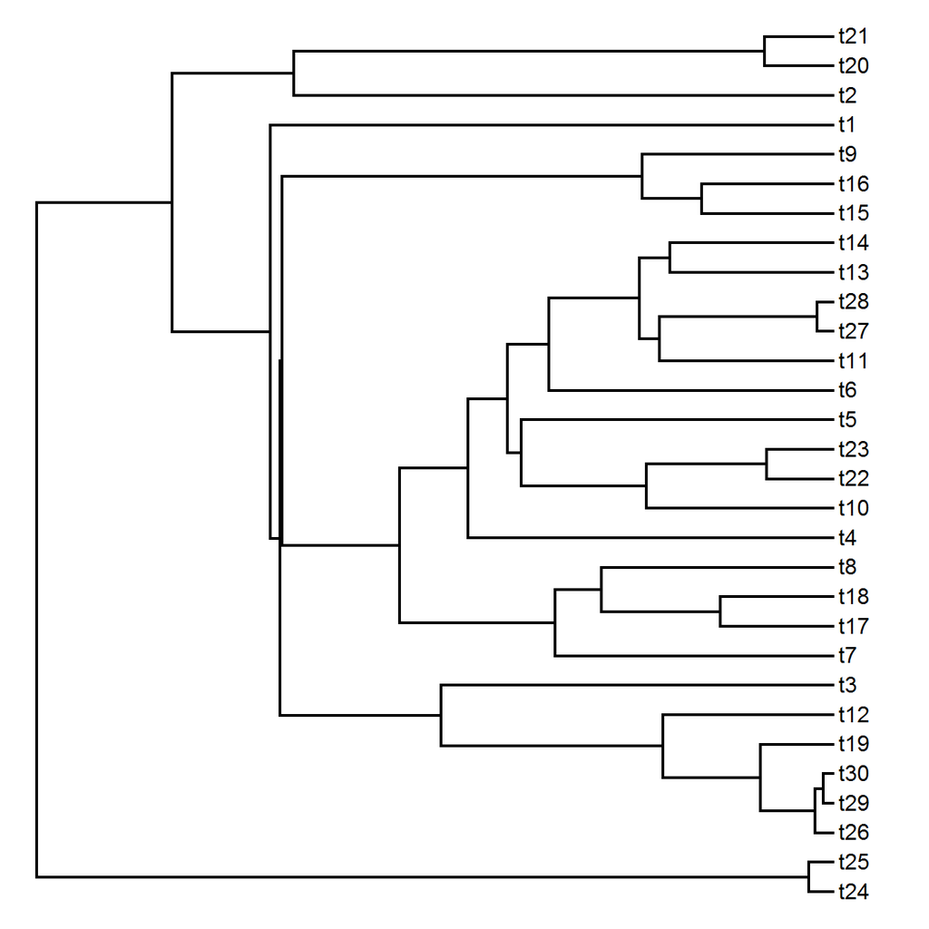

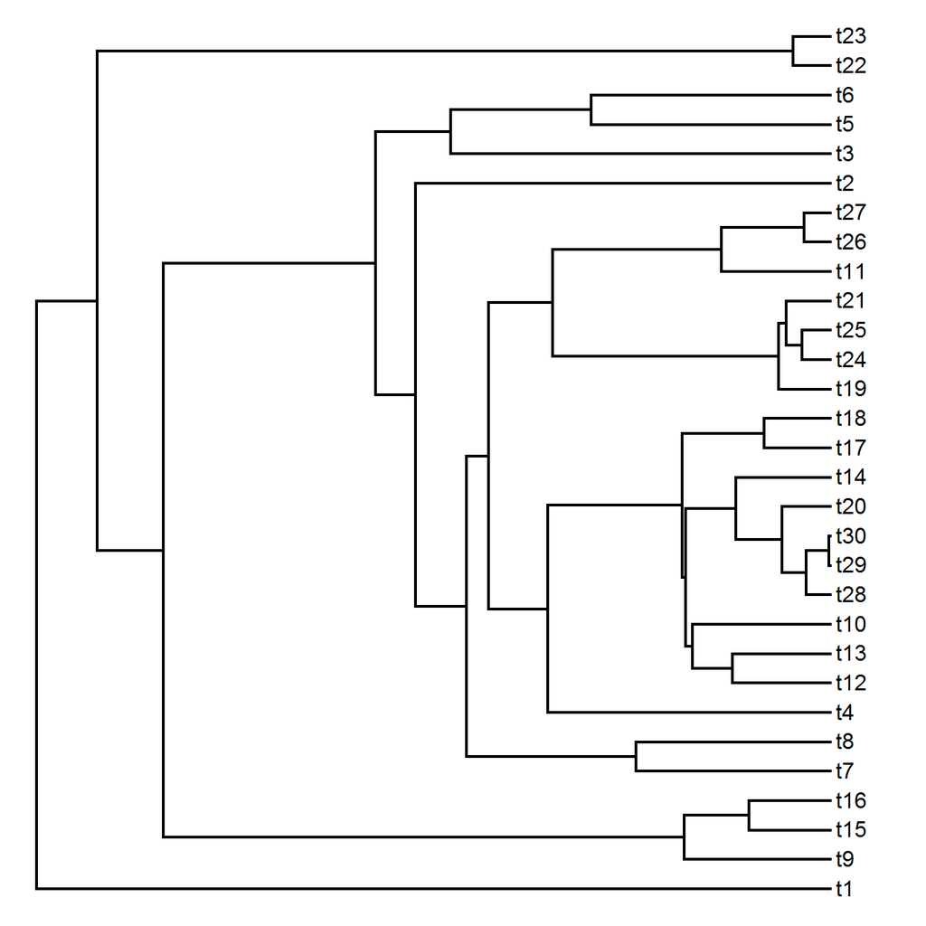

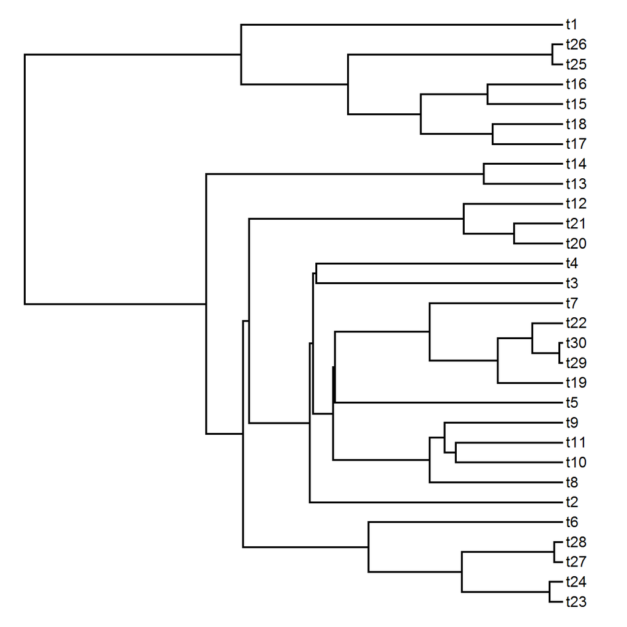

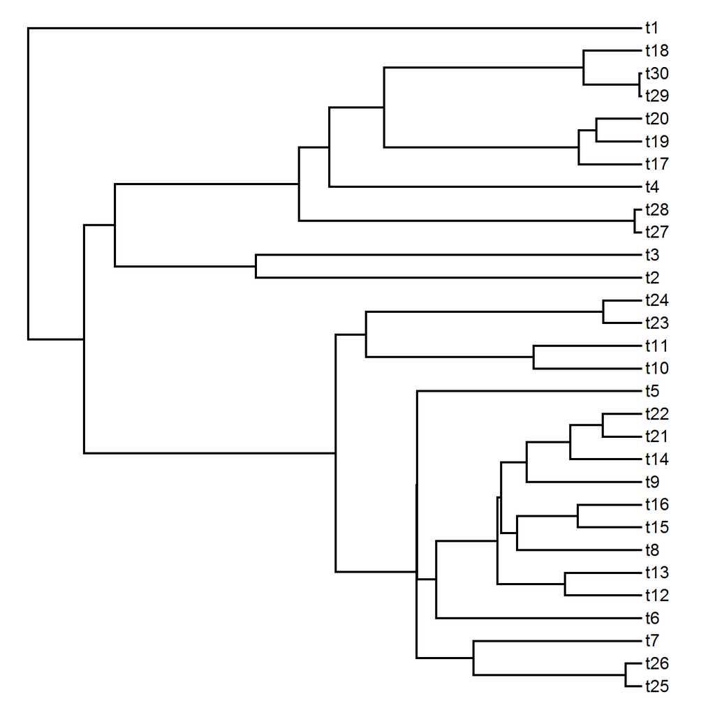

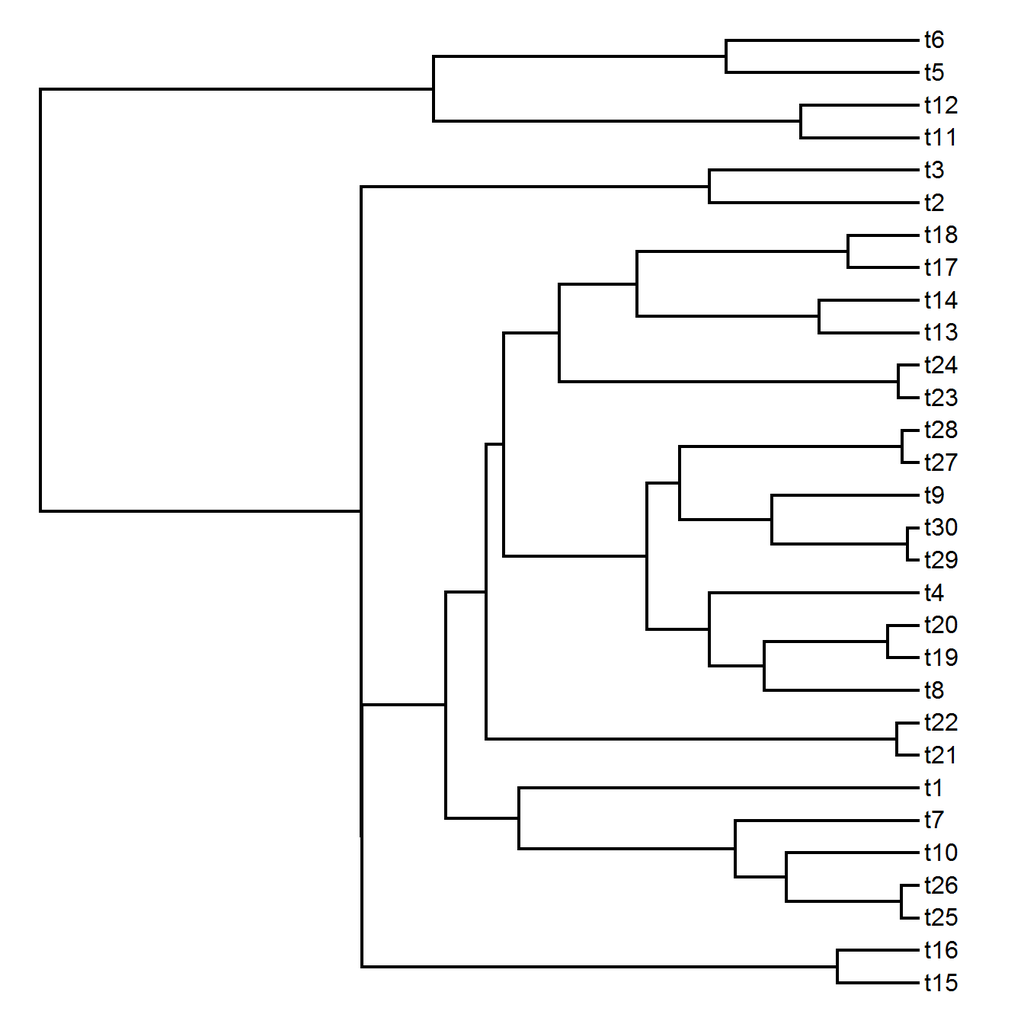

```r
plotTree(trees.unbalanced[1:5], main="Unbalanced trees")
```

### 3) Simulate a morphological trend and do ancestral state reconstruction (assuming Brownian motion). Then calculate the slope of node morphology against time.

```r
a <- 0
mu <- 0.01
sig2 <- 0.01
n.iter<- 100

balance.res <- slope.func(tree.list=trees.balanced, a=a, mu=mu, sig2=sig2, n.iter=n.iter)
unbalance.res <- slope.func(tree.list=trees.unbalanced, a=a, mu=mu, sig2=sig2, n.iter=n.iter)
```

### 4) Let’s first see if there are any differences in slope (i.e., degree of trendedness) between balanced and unbalanced trees in terms of the mean difference between “true” node morphologies and reconstructed ancestral states.

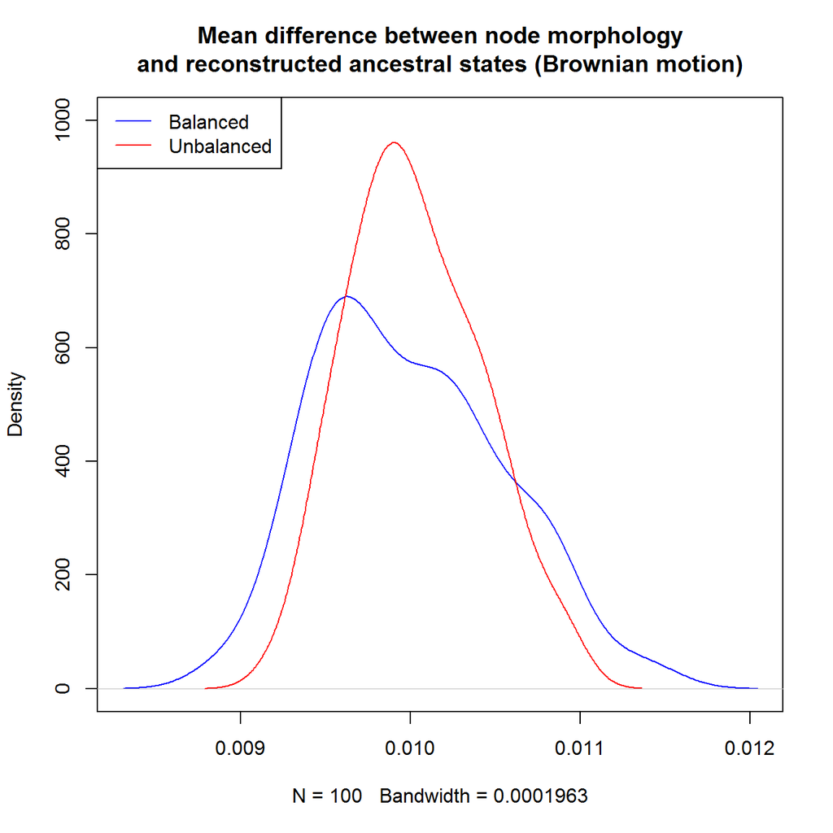

```r
balance.mean.diff <- numeric(dim(balance.res)[2])

for(i in seq_along(balance.mean.diff)) balance.mean.diff[i] <- mean(balance.res[1, i, ]) - mean(balance.res[2, i, ])

unbalance.mean.diff <- numeric(dim(unbalance.res)[2])

for(i in seq_along(unbalance.mean.diff)) unbalance.mean.diff[i] <- mean(unbalance.res[1, i, ]) - mean(unbalance.res[2, i, ])

plot(density(balance.mean.diff), main="Mean difference between node morphology\nand reconstructed ancestral states (Brownian motion)", col="blue", ylim=c(0, 1000))
lines(density(unbalance.mean.diff), col="red")

legend("topleft", c("Balanced", "Unbalanced"), lty=c(1, 1), col=c("blue", "red"))
```

#### Results show that perhaps on average, unbalanced trees show a more marked divergence between trendedness of “true” node morphologies and reconstructed ancestral states, but the difference is pretty small. Overall, there is no real difference related to tree structure (i.e., unbalanced vs. balanced).

### 5) Now let’s see of there’s any difference in the variance of slopes (i.e., degree of trendedness) between different combinations of (un)balanced trees and ancestral states (“real” or reconstructed).

```r
balance.sd <- apply(balance.res, c(1, 3), var)
dim(balance.sd)
```

```
## [1]  2 47
```

```r
unbalance.sd <- apply(unbalance.res, c(1, 3), var)
dim(unbalance.sd)
```

```
## [1]  2 94
```

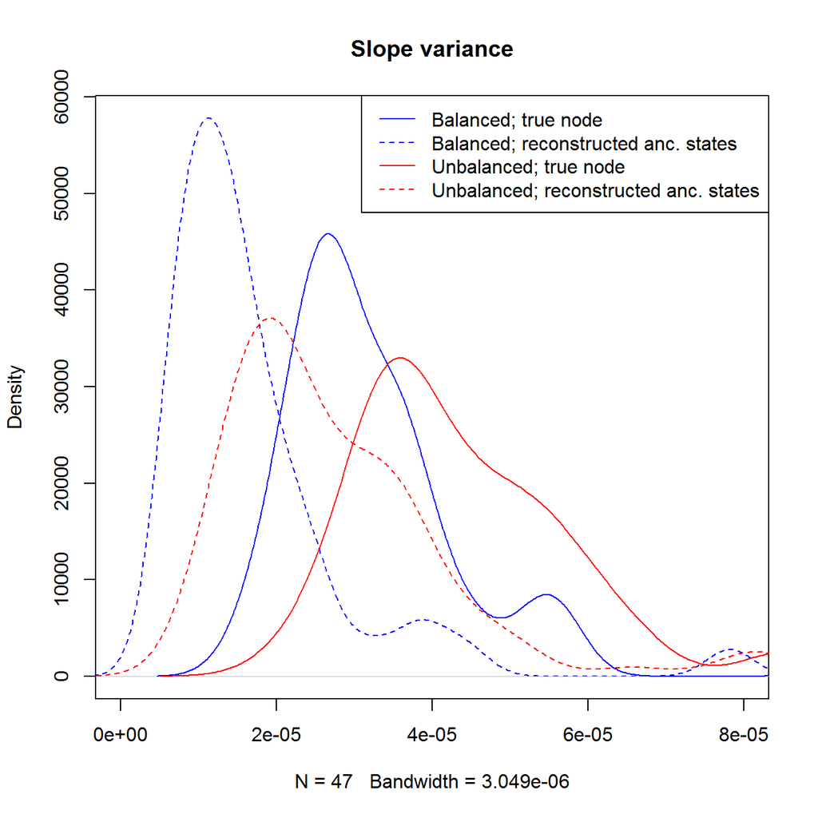

```r
plot(density(balance.sd[2, ]), main="Slope variance", col="blue", lty=2, xlim=c(0, 8e-5))
lines(density(balance.sd[1, ]), col="blue")

lines(density(unbalance.sd[1, ]), col="red")
lines(density(unbalance.sd[2, ]), col="red", lty=2)

legend("topright", c("Balanced; true node", "Balanced; reconstructed anc. states", "Unbalanced; true node", "Unbalanced; reconstructed anc. states"), lty=c(1, 2, 1, 2), col=c("blue", "blue", "red", "red"))
```

#### Result show on average, reconstructed ancestral states have a lower variance in slope (i.e., degree of trendedness), and the same is true of balanced tress relative to unbalanced ones. Therefore, the variance of how strong temporal trends are related to these two factors.

### In conclusion, one cannot recover the true underlying trend when reconstructing ancestral states assuming a Brownian motion model and then regressing these ancestral states vs. branching times. This is ultimately due to the Brownian motion model which assumes no change on average. This result does not change as a function of tree structure (at least when it comes to how balanced it is), but the variance of the trend will vary.